# Gapminder Exploratory Data Analysis

**Use the dplyr package to perform data transformation and manipulation operations.** **Use the ggplot package to visually analyze our data.**

## Load Packages

```r
#install.packages("gapminder")
library(gapminder)
library(dplyr)
library(ggplot2)
```

The variables are explained as follows: Country - factor with 142 levels Continent - Factor with 5 levels Year - ranges from 1952 to 2007 in increments of 5 years lifeExp - life expectancy at birth, in years pop - population dgoPercap - GDP per capita

```r
kableExtra::kable(head(gapminder))
```

| country | continent | year | lifeExp | pop | gdpPercap |
| --- | --- | --- | --- | --- | --- |
| Afghanistan | Asia | 1952 | 28.801 | 8425333 | 779.4453 |
| Afghanistan | Asia | 1957 | 30.332 | 9240934 | 820.8530 |
| Afghanistan | Asia | 1962 | 31.997 | 10267083 | 853.1007 |
| Afghanistan | Asia | 1967 | 34.020 | 11537966 | 836.1971 |
| Afghanistan | Asia | 1972 | 36.088 | 13079460 | 739.9811 |
| Afghanistan | Asia | 1977 | 38.438 | 14880372 | 786.1134 |

```r
head(gapminder_unfiltered,5) #Unfiltered data
```

| country | continent | year | lifeExp | pop | gdpPercap |
| --- | --- | --- | --- | --- | --- |
| Afghanistan | Asia | 1952 | 28.801 | 8425333 | 779.4453 |
| Afghanistan | Asia | 1957 | 30.332 | 9240934 | 820.8530 |
| Afghanistan | Asia | 1962 | 31.997 | 10267083 | 853.1007 |
| Afghanistan | Asia | 1967 | 34.020 | 11537966 | 836.1971 |
| Afghanistan | Asia | 1972 | 36.088 | 13079460 | 739.9811 |

```r
tail(gapminder_unfiltered,5)
```

| country | continent | year | lifeExp | pop | gdpPercap |
| --- | --- | --- | --- | --- | --- |
| Zimbabwe | Africa | 1987 | 62.351 | 9216418 | 706.1573 |
| Zimbabwe | Africa | 1992 | 60.377 | 10704340 | 693.4208 |
| Zimbabwe | Africa | 1997 | 46.809 | 11404948 | 792.4500 |
| Zimbabwe | Africa | 2002 | 39.989 | 11926563 | 672.0386 |
| Zimbabwe | Africa | 2007 | 43.487 | 12311143 | 469.7093 |

## Display name of Variables :

```r
names(gapminder_unfiltered)
```

```
[1] "country"   "continent" "year"      "lifeExp"   "pop"       "gdpPercap"
```

## Data Cleaning :

**Finding the missing values** as we can see this data has no missing values

```r
sum(is.na(gapminder_unfiltered))
```

```
[1] 0
```

**Display the continent , country and year**

| year | country | continent |
| --- | --- | --- |
| 1952 | Afghanistan | Asia |
| 1957 | Afghanistan | Asia |
| 1962 | Afghanistan | Asia |
| 1967 | Afghanistan | Asia |
| 1972 | Afghanistan | Asia |
| 1977 | Afghanistan | Asia |
| 1982 | Afghanistan | Asia |
| 1987 | Afghanistan | Asia |
| 1992 | Afghanistan | Asia |
| 1997 | Afghanistan | Asia |

[output cut: 990 more lines]

## Data-Set

**Structure**

```r
glimpse(gapminder_unfiltered)
```

```
Rows: 3,313
Columns: 6
$ country   <fct> Afghanistan, Afghanistan, Afghanistan, Afghanistan, Afghanistan, Afghan...
$ continent <fct> Asia, Asia, Asia, Asia, Asia, Asia, Asia, Asia, Asia, Asia, Asia, Asia,...
$ year      <int> 1952, 1957, 1962, 1967, 1972, 1977, 1982, 1987, 1992, 1997, 2002, 2007,...
$ lifeExp   <dbl> 28.801, 30.332, 31.997, 34.020, 36.088, 38.438, 39.854, 40.822, 41.674,...
$ pop       <int> 8425333, 9240934, 10267083, 11537966, 13079460, 14880372, 12881816, 138...
$ gdpPercap <dbl> 779.4453, 820.8530, 853.1007, 836.1971, 739.9811, 786.1134, 978.0114, 8...
```

**Summary** **Calculating descriptive statistics using describe()**

```r
describe(gapminder_unfiltered)
```

```
gapminder_unfiltered

 6  Variables      3313  Observations
----------------------------------------------------------------------------------------------
country
       n  missing distinct
    3313        0      187

lowest : Afghanistan        Albania            Algeria            Angola             Argentina
highest: Vietnam            West Bank and Gaza Yemen, Rep.        Zambia             Zimbabwe
----------------------------------------------------------------------------------------------
continent
       n  missing distinct
    3313        0        6

lowest : Africa   Americas Asia     Europe   FSU     , highest: Americas Asia     Europe   FSU      Oceania

Value        Africa Americas     Asia   Europe      FSU  Oceania
Frequency       637      470      578     1302      139      187
Proportion    0.192    0.142    0.174    0.393    0.042    0.056
----------------------------------------------------------------------------------------------
year
       n  missing distinct     Info     Mean      Gmd      .05      .10      .25      .50
    3313        0       58    0.998     1980    19.52     1952     1957     1967     1982
     .75      .90      .95
    1996     2002     2007

lowest : 1950 1951 1952 1953 1954, highest: 2003 2004 2005 2006 2007
----------------------------------------------------------------------------------------------
lifeExp
       n  missing distinct     Info     Mean      Gmd      .05      .10      .25      .50
    3313        0     2571        1    65.24    12.73    41.22    45.37    58.33    69.61
     .75      .90      .95
   73.66    77.12    78.68

lowest : 23.599 28.801 30.000 30.015 30.331, highest: 82.208 82.270 82.360 82.603 82.670
----------------------------------------------------------------------------------------------
pop
        n   missing  distinct      Info      Mean       Gmd       .05       .10       .25
     3313         0      3312         1  31773251  50168977    235605    436150   2680018
      .50       .75       .90       .95
  7559776  19610538  56737055 121365965

lowest :      59412      59461      60011      60427      61325
highest: 1110396331 1164970000 1230075000 1280400000 1318683096
----------------------------------------------------------------------------------------------
gdpPercap
       n  missing distinct     Info     Mean      Gmd      .05      .10      .25      .50
    3313        0     3313        1    11314    11542    665.7    887.9   2505.3   7825.8
     .75      .90      .95
 17355.7  26592.7  31534.9

lowest :    241.1659    277.5519    298.8462    299.8503    312.1884
highest:  82010.9780  95458.1118 108382.3529 109347.8670 113523.1329
----------------------------------------------------------------------------------------------
```

– ## Exploratory Data Analysis **Plots**

[figure not shown]

```r
jpeg("10.jpeg")
plot(lifeExp ~ log(gdpPercap),col = gdpPercap)

dev.off()
```

```r
jpeg("8.jpeg")
plot(gapminder_unfiltered)
dev.off()
```

**For the year 2007, what is the distribution of GDP per capita across all countries?**

```r
jpeg("12.jpeg")
ggplot(GDP_2007 ,aes(x =gdpPercap ))+geom_histogram( fill= "cyan" , bins = 40)+ ggtitle("Distribution of GDP per capita across all countries for 2007")+ylab("GDP per Capita")+
            theme(axis.title.x=element_blank(),
                                            axis.text.x=element_blank(),
                                            axis.ticks.x=element_blank())
dev.off()
```

```r
jpeg("13.jpeg")
ggplot(GDP_2007, aes(x=country, y=gdpPercap)) + geom_point(aes(color = continent)) +
                                              ylab("GDP per Capita") +
                                              ggtitle("GDP Per Capita for Contries grouped by Continents for 2007") +
                                              theme(axis.title.x=element_blank(),
                                                    axis.text.x=element_blank(),
                                                    axis.ticks.x=element_blank())
dev.off()
```

**For the year 2007, how do the distributions differ across the different continents?**

```r
jpeg("14.jpeg")
ggplot(GDP_2007, aes(x=continent, y=gdpPercap)) + geom_bar(fill = "green",stat = "identity") +
                                                  xlab("Continents") +
                                                  ylab("GDP per Capita") +
                                                  ggtitle("GDP Per Capita vs Continents for 2007")
dev.off()
```

[figure not shown]

**For the year 2007, what are the top 10 countries with the largest GDP per capita?**

[output not shown]

```r
top_10_gdpc<- GDP_2007[order(GDP_2007$gdpPercap , decreasing = TRUE),2:3][1:10,]
#,2:3 select col 2 to 3 only and show 1:10 entries
top_10_gdpc


#we can see the GDP per capita for specific country like this...
GDP_2007[GDP_2007$country == "India",]
```

| continent | country | gdpPercap |
| --- | --- | --- |
| Asia | India | 2452.21 |

```r
NA
```

**Top 10 GDPpercap by country**

```r
jpeg("16.jpeg")
ggplot(top_10_gdpc, aes(x=country, y=gdpPercap)) +
  geom_bar(fill="palegreen2", stat = "identity") +
  xlab("Top 10 Countries") +ylab("GDP per Capita") +
  ggtitle("Top 10 GDP Per Capita vs Countries")
dev.off()
```

**Plot the GDP per capita for your country of origin for all years available**

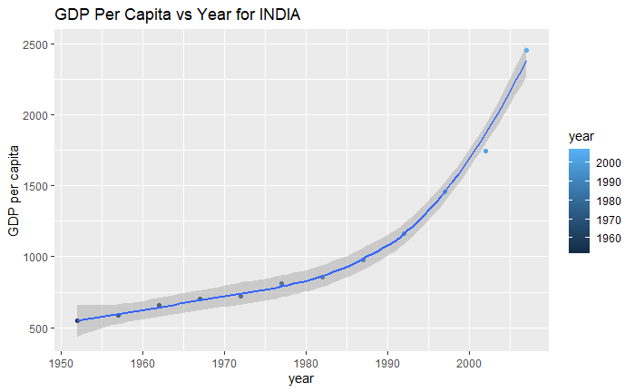

**gdppercal less than 50000 ,lifeExp and Continent**

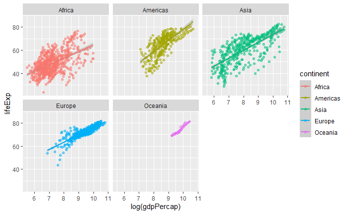

**gdppercal less than 50000 ,lifeExp and year**

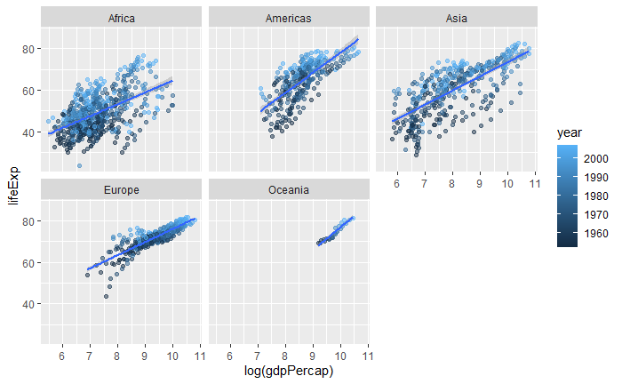

##Life Expectancy of countries :

[output not shown]

```r
library(dplyr)
gapminder_unfiltered %>%
  select(country , lifeExp) %>% filter(country == "United States" | country== "India" )%>% group_by( country) %>% summarise( avg_lifeExp = mean(lifeExp))
```

## check the life Expectany : using T test :

```r
df1 <- gapminder_unfiltered %>%
  select(country , lifeExp) %>% filter(country == "United States" | country== "India" )

t.test(data = df1 ,lifeExp ~ country )
```

```
    Welch Two Sample t-test

data:  lifeExp by country
t = -7.4119, df = 11.511, p-value = 1.035e-05
alternative hypothesis: true difference in means is not equal to 0
95 percent confidence interval:
 -25.95014 -14.11636
sample estimates:
        mean in group India mean in group United States
                   53.16608                    73.19933
```

**Bonus Information** Just Introduction : ## Regression :

##single variat

```r
summary(lm(lifeExp ~ gdpPercap))
```

```
Call:
lm(formula = lifeExp ~ gdpPercap)

Residuals:
    Min      1Q  Median      3Q     Max
-82.754  -7.758   2.176   8.225  18.426

Coefficients:
             Estimate Std. Error t value Pr(>|t|)
(Intercept) 5.396e+01  3.150e-01  171.29   <2e-16 ***
gdpPercap   7.649e-04  2.579e-05   29.66   <2e-16 ***
---
Signif. codes:  0 ‘***’ 0.001 ‘**’ 0.01 ‘*’ 0.05 ‘.’ 0.1 ‘ ’ 1

Residual standard error: 10.49 on 1702 degrees of freedom
Multiple R-squared:  0.3407,    Adjusted R-squared:  0.3403
F-statistic: 879.6 on 1 and 1702 DF,  p-value: < 2.2e-16
```

##Multi variat

```r
summary(lm(lifeExp ~ gdpPercap+pop+continent))
```

```
Call:
lm(formula = lifeExp ~ gdpPercap + pop + continent)

Residuals:
    Min      1Q  Median      3Q     Max
-49.161  -4.486   0.297   5.110  25.175

Coefficients:
                   Estimate Std. Error t value Pr(>|t|)
(Intercept)       4.781e+01  3.395e-01 140.819  < 2e-16 ***
gdpPercap         4.495e-04  2.346e-05  19.158  < 2e-16 ***
pop               6.570e-09  1.975e-09   3.326 0.000901 ***
continentAmericas 1.348e+01  6.000e-01  22.458  < 2e-16 ***
continentAsia     8.193e+00  5.712e-01  14.342  < 2e-16 ***
continentEurope   1.747e+01  6.246e-01  27.973  < 2e-16 ***
continentOceania  1.808e+01  1.782e+00  10.146  < 2e-16 ***
---
Signif. codes:  0 ‘***’ 0.001 ‘**’ 0.01 ‘*’ 0.05 ‘.’ 0.1 ‘ ’ 1

Residual standard error: 8.365 on 1697 degrees of freedom
Multiple R-squared:  0.5821,    Adjusted R-squared:  0.5806
F-statistic: 393.9 on 6 and 1697 DF,  p-value: < 2.2e-16
```